# IODS course project

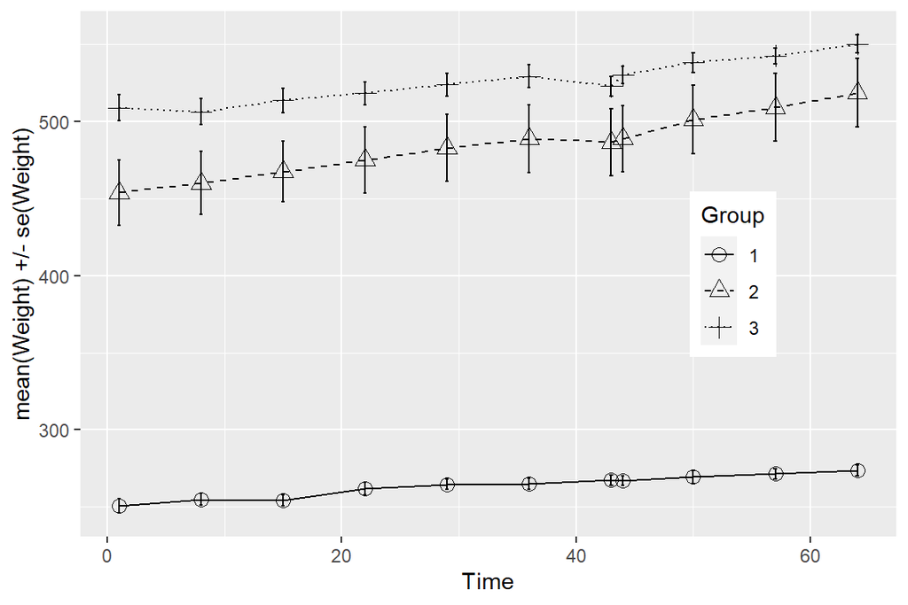

```r
ggplot(RATSS, aes(x = Time, y = mean, linetype = Group, shape = Group)) +
  geom_line() +
  scale_linetype_manual(values = c(1,2,3)) +
  geom_point(size=3) +
  scale_shape_manual(values = c(1,2,3)) +
  geom_errorbar(aes(ymin=mean-se, ymax=mean+se, linetype="1"), width=0.3) +
  theme(legend.position = c(0.8,0.5)) +
  scale_y_continuous(name = "mean(Weight) +/- se(Weight)")
```

With this summarizing method we get the means of weights (variable *mean*)for each diet group for each measurement point, and the standard errors of the weights (variable *se*) for each diet group for each measurement point. From this line plot I see that all the groups differ from one another in every measurement point (the standard errors don’t overlap), and the difference remains pretty similar from the beginning to the end. However, it also seems that group 2 is coming a little bit closer to group 3 during the measurement period.

The clear difference between the groups doesn’t necessarily tell us that one diet is better than another, since some differences between the weight gain rate might reflect the initial differences between the rats.

Next, I’ll form the summary variable (mean) for body weights of measurements from days 8-64 (later, I’ll consider the measurement of day 1 the baseline), and plot the means to track potential outliers.

```r
RATSL8S <- RATSL %>%
  filter(Time > 1) %>%
  group_by(Group, ID) %>%
  summarise(mean=mean(Weight) ) %>%
  ungroup()
glimpse(RATSL8S)
```

```
## Rows: 16
## Columns: 3
## $ Group <fct> 1, 1, 1, 1, 1, 1, 1, 1, 2, 2, 2, 2, 3, 3, 3, 3
## $ ID    <fct> 1, 2, 3, 4, 5, 6, 7, 8, 9, 10, 11, 12, 13, 14, 15, 16
## $ mean  <dbl> 263.2, 238.9, 261.7, 267.2, 270.9, 276.2, 274.6, 267.5, 443.9...
```

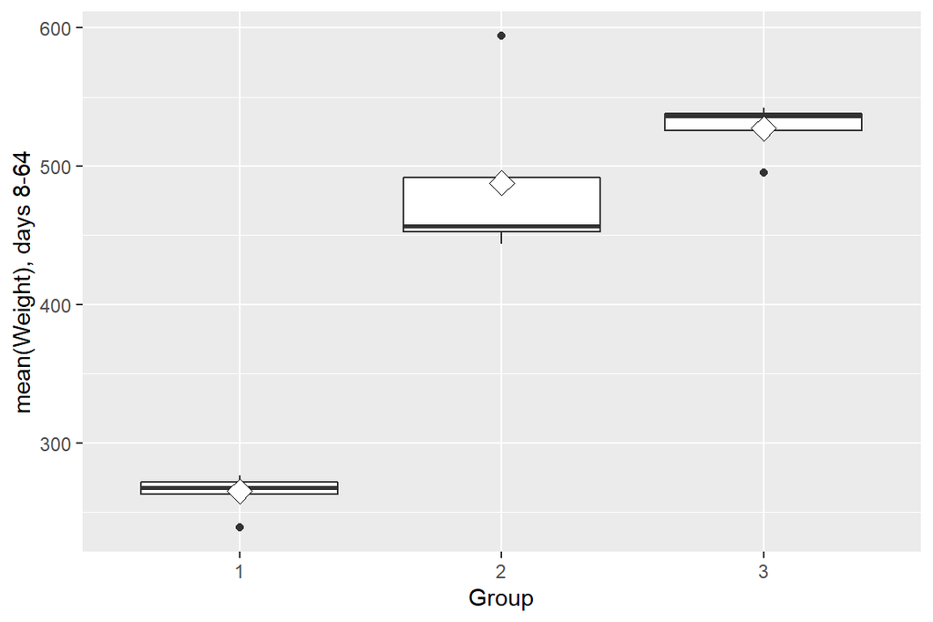

```r
ggplot(RATSL8S, aes(x = Group, y = mean)) +
  geom_boxplot() +
  stat_summary(fun.y = "mean", geom = "point", shape=23, size=4, fill = "white") +
  scale_y_continuous(name = "mean(Weight), days 8-64")
```

I see that there are three outliers, one in every group. To exclude the outliers, I came up with two methods: 1) to spot the outlier IDs and filter those IDs out or to set a weight limit for each group separately. I chose to do the latter. Then I’ll draw new boxplots to see the distributions without outliers. I’ll draw one picture with all the distributions to be able to compare the location of the distributions, and also three separate pictures to be able to explore each distribution more clearly.

```r
RATSL8S
```

```
## # A tibble: 16 x 3
##    Group ID     mean
##    <fct> <fct> <dbl>
##  1 1     1      263.
##  2 1     2      239.
##  3 1     3      262.
##  4 1     4      267.
##  5 1     5      271.
##  6 1     6      276.
##  7 1     7      275.
##  8 1     8      268.
##  9 2     9      444.
## 10 2     10     458.
## 11 2     11     456.
## 12 2     12     594
## 13 3     13     495.
## 14 3     14     536.
## 15 3     15     542.
## 16 3     16     536.
```

```r
group1 <- RATSL8S[RATSL8S$Group == 1,]
group2 <- RATSL8S[RATSL8S$Group == 2,]
group3 <- RATSL8S[RATSL8S$Group == 3,]


group1_ <- dplyr::filter(group1, mean > 250)
group2_ <- dplyr::filter(group2, mean < 550)
group3_ <- dplyr::filter(group3, mean > 500)


RATSL8S1 <- rbind(group1_, group2_, group3_)

is.data.frame(RATSL8S1)
```

```
## [1] TRUE
```

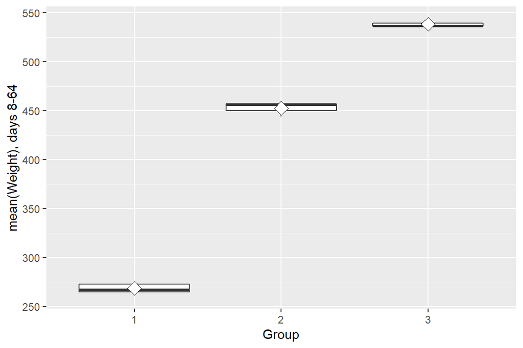

```r
ggplot(RATSL8S1, aes(x = Group, y = mean)) +
  geom_boxplot() +
  stat_summary(fun.y = "mean", geom = "point", shape=23, size=4, fill = "white") +
  scale_y_continuous(name = "mean(Weight), days 8-64")
```

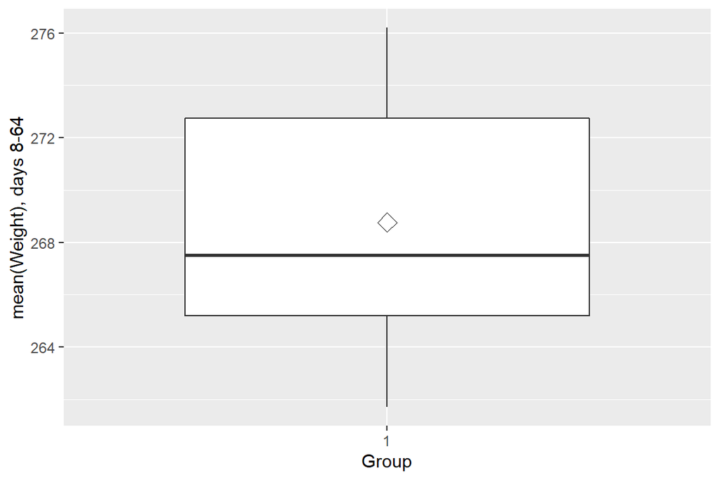

```r
ggplot(group1_, aes(x = Group, y = mean)) +
  geom_boxplot() +
  stat_summary(fun.y = "mean", geom = "point", shape=23, size=4, fill = "white") +
  scale_y_continuous(name = "mean(Weight), days 8-64")
```

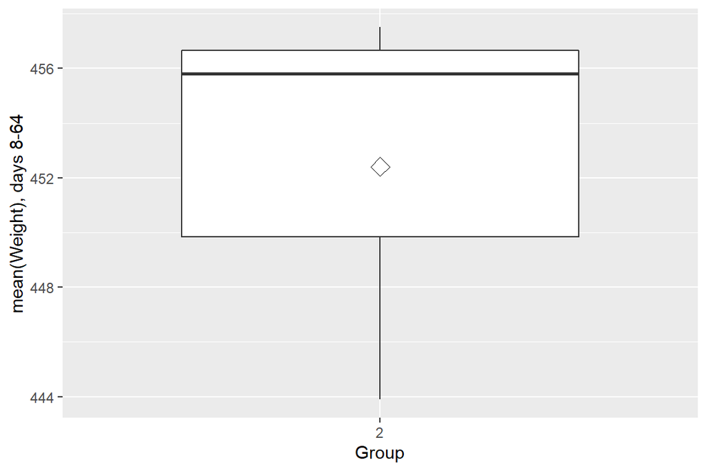

```r
ggplot(group2_, aes(x = Group, y = mean)) +
  geom_boxplot() +
  stat_summary(fun.y = "mean", geom = "point", shape=23, size=4, fill = "white") +
  scale_y_continuous(name = "mean(Weight), days 8-64")
```

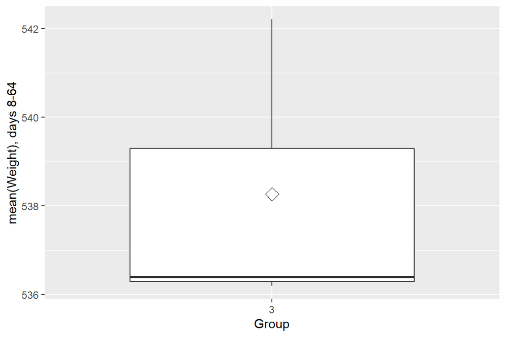

```r
ggplot(group3_, aes(x = Group, y = mean)) +
  geom_boxplot() +
  stat_summary(fun.y = "mean", geom = "point", shape=23, size=4, fill = "white") +
  scale_y_continuous(name = "mean(Weight), days 8-64")
```

```r
var(group1_$mean)
```

```
## [1] 29.80286
```

```r
var(group2_$mean)
```

```
## [1] 54.91
```

```r
var(group3_$mean)
```

```
## [1] 11.61333
```

```r
RATSL8S2 <- RATSL8S %>%
  mutate(baseline = RATS$WD1)

oneway.test(mean ~ Group, data = RATSL8S2, var.equal = F)
```

```
##
##  One-way analysis of means (not assuming equal variances)
##
## data:  mean and Group
## F = 234.99, num df = 2.000, denom df = 4.572, p-value = 2.46e-05
```

```r
fit <- lm(mean ~ baseline + Group, data = RATSL8S2)

summary(fit)
```

```
##
## Call:
## lm(formula = mean ~ baseline + Group, data = RATSL8S2)
##
## Residuals:
##     Min      1Q  Median      3Q     Max
## -23.905  -4.194   2.190   7.577  14.800
##
## Coefficients:
##             Estimate Std. Error t value Pr(>|t|)
## (Intercept) 33.16375   21.87657   1.516   0.1554
## baseline     0.92513    0.08572  10.793 1.56e-07 ***
## Group2      34.85753   18.82308   1.852   0.0888 .
## Group3      23.67526   23.25324   1.018   0.3287
## ---
## Signif. codes:  0 '***' 0.001 '**' 0.01 '*' 0.05 '.' 0.1 ' ' 1
##
## Residual standard error: 11.68 on 12 degrees of freedom
## Multiple R-squared:  0.9936, Adjusted R-squared:  0.992
## F-statistic: 622.1 on 3 and 12 DF,  p-value: 1.989e-13
```

```r
anova(fit)
```

```
## Analysis of Variance Table
##
## Response: mean
##           Df Sum Sq Mean Sq   F value   Pr(>F)
## baseline   1 253625  253625 1859.8201 1.57e-14 ***
## Group      2    879     439    3.2219  0.07586 .
## Residuals 12   1636     136
## ---
## Signif. codes:  0 '***' 0.001 '**' 0.01 '*' 0.05 '.' 0.1 ' ' 1
```

The result of the variance analysis means that

- there is a statistical difference between the means of at least some of the groups; the weights of the rats on different diets differ on average from each other (at least there is a difference between some of the groups)
- however, with this summary method it is not possible to reason whether this difference comes from the diet or from different qualities/starting points of the rats

The results of the linear model and related anova mean that

- the differences in the *baseline* (day 1) measure of the weight have a statistical impact on the summary measure (mean weight of measurements from days 8-64)
- the *Group* coefficient doesn’t reach significance. This means that when the difference in baseline weights is taken into account, different diets don’t explain significantly the mean weight of the following days

## BPRS

I’ll read the data to R, transform subject numbers of group 2 from 1-20 to 21-40 (for the purposes of later analysis), convert categorical variables to factors and explore the data a little.

```r
BPRSL <- read.csv("data/BPRSL.csv", row.names = 1)
head(BPRSL)
```

```
##   treatment subject weeks bprs week
## 1         1       1 week0   42    0
## 2         1       2 week0   58    0
## 3         1       3 week0   54    0
## 4         1       4 week0   55    0
## 5         1       5 week0   72    0
## 6         1       6 week0   48    0
```

```r
BPRSL_t1 <- dplyr::filter(BPRSL, treatment == 1)

BPRSL_t2 <- dplyr::filter(BPRSL, treatment == 2)
BPRSL_t2 <- mutate(BPRSL_t2, Subject = subject+20)
BPRSL_t2$subject <- BPRSL_t2$Subject
BPRSL_t2 <- dplyr::select(BPRSL_t2, -Subject)

BPRSL <- rbind(BPRSL_t1, BPRSL_t2)

BPRSL <- BPRSL %>% mutate(treatment = as.factor(BPRSL$treatment)) %>% mutate(subject = as.factor(BPRSL$subject))
str(BPRSL)
```

```
## 'data.frame':    360 obs. of  5 variables:
##  $ treatment: Factor w/ 2 levels "1","2": 1 1 1 1 1 1 1 1 1 1 ...
##  $ subject  : Factor w/ 40 levels "1","2","3","4",..: 1 2 3 4 5 6 7 8 9 10 ...
##  $ weeks    : chr  "week0" "week0" "week0" "week0" ...
##  $ bprs     : int  42 58 54 55 72 48 71 30 41 57 ...
##  $ week     : int  0 0 0 0 0 0 0 0 0 0 ...
```

The BPRSL data contains information about the development of psychiatric symptoms (measured by bprs-questionnaire) of patients that have been randomized to two different treatments. The data is collected during a period of 8 weeks (+ baseline measure, altogether 9 measurements). There were 40 subjects in the study. The data is in the long form, so there is a row for each measurement for each subject.

Next, I’ll explore the variability of the bprs scores based on time and treatments (with linear regression). At this point, I’ll still ignore the repeated measure structure of the data.

```r
BPRS_reg <- lm(bprs ~ week + treatment, data = BPRSL)

summary(BPRS_reg)
```

```
##
## Call:
## lm(formula = bprs ~ week + treatment, data = BPRSL)
##
## Residuals:
##     Min      1Q  Median      3Q     Max
## -22.454  -8.965  -3.196   7.002  50.244
##
## Coefficients:
##             Estimate Std. Error t value Pr(>|t|)
## (Intercept)  46.4539     1.3670  33.982   <2e-16 ***
## week         -2.2704     0.2524  -8.995   <2e-16 ***
## treatment2    0.5722     1.3034   0.439    0.661
## ---
## Signif. codes:  0 '***' 0.001 '**' 0.01 '*' 0.05 '.' 0.1 ' ' 1
##
## Residual standard error: 12.37 on 357 degrees of freedom
## Multiple R-squared:  0.1851, Adjusted R-squared:  0.1806
## F-statistic: 40.55 on 2 and 357 DF,  p-value: < 2.2e-16
```

The results of this *simple regression model* suggest that…

- there is no difference in bprs scores between the groups
- variable week that indicates the effects of time is significant: this means that time has an impact on the scores in bprs.

Next I’ll take a look at the data with some line plots that take account into the repeated-measures structure of the data.

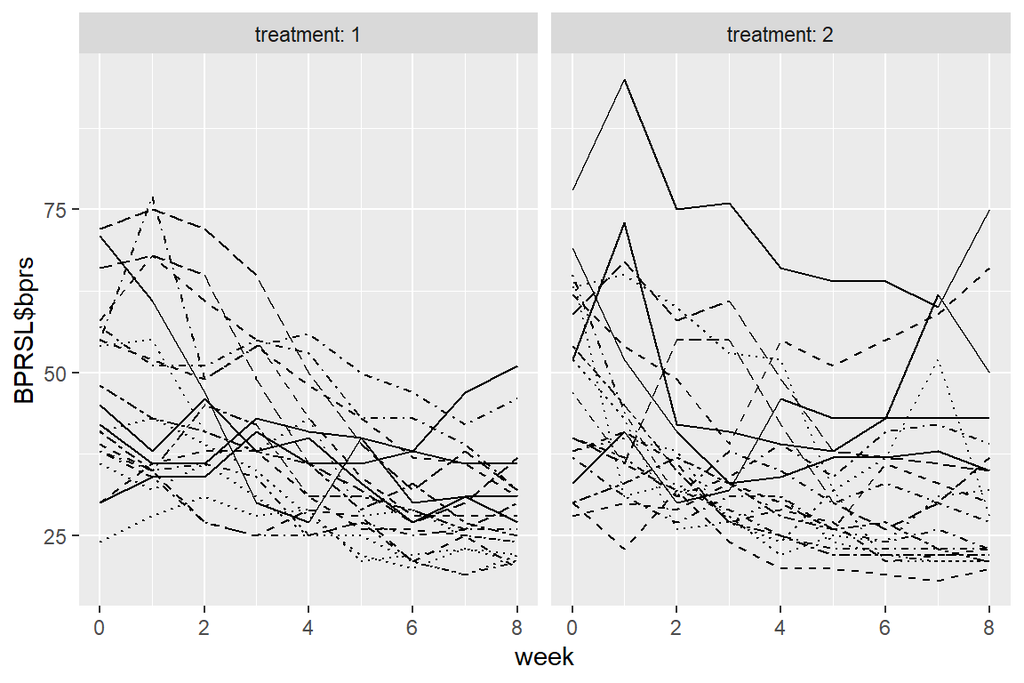

```r
ggplot(BPRSL, aes(x = week, y = BPRSL$bprs, linetype = subject)) +
  geom_line() +
  scale_linetype_manual(values = rep(1:10, times=4)) +
  facet_grid(. ~ treatment, labeller = label_both) +
  theme(legend.position = "none") +
  scale_y_continuous(limits = c(min(BPRSL$bprs), max(BPRSL$bprs)))
```

From these plots I see that the variability of bprs scores decreases a little over the measurements. Roughly evaluating, the mean scores of the two groups look somewhat similar. Also it would seem that the scores decrease to some extent over time in both groups. In treatment group 2 there seems to be a bit more variability and more bumps in the trajectories than in group 1. I also see that the trajectories of the patients are unique and all of them don’t follow the average direction.

Next, I’ll move on to *the random intercept model* in which the model allows a unique intercept for each subject. This way the model takes into account that there might be initial differences between the patients (between-individual heterogeneity). After this I’ll fit *the random intercept and random slope model*, which, in addition, makes it possible to account for the effects of time (within-individual biological variation).

```r
BPRS_ref <- lmer(bprs ~ week + treatment + (1 | subject), data = BPRSL, REML = FALSE)

summary(BPRS_ref)
```

```
## Linear mixed model fit by maximum likelihood  ['lmerMod']
## Formula: bprs ~ week + treatment + (1 | subject)
##    Data: BPRSL
##
##      AIC      BIC   logLik deviance df.resid
##   2582.9   2602.3  -1286.5   2572.9      355
##
## Scaled residuals:
##      Min       1Q   Median       3Q      Max
## -2.27506 -0.59909 -0.06104  0.44226  3.15835
##
## Random effects:
##  Groups   Name        Variance Std.Dev.
##  subject  (Intercept) 97.39    9.869
##  Residual             54.23    7.364
## Number of obs: 360, groups:  subject, 40
##
## Fixed effects:
##             Estimate Std. Error t value
## (Intercept)  46.4539     2.3521  19.750
## week         -2.2704     0.1503 -15.104
## treatment2    0.5722     3.2159   0.178
##
## Correlation of Fixed Effects:
##            (Intr) week
## week       -0.256
## treatment2 -0.684  0.000
```

```r
BPRS_ref1 <- lmer(bprs ~ week + treatment + (week | subject), data = BPRSL, REML = FALSE)

summary(BPRS_ref1)
```

```
## Linear mixed model fit by maximum likelihood  ['lmerMod']
## Formula: bprs ~ week + treatment + (week | subject)
##    Data: BPRSL
##
##      AIC      BIC   logLik deviance df.resid
##   2523.2   2550.4  -1254.6   2509.2      353
##
## Scaled residuals:
##     Min      1Q  Median      3Q     Max
## -2.4655 -0.5150 -0.0920  0.4347  3.7353
##
## Random effects:
##  Groups   Name        Variance Std.Dev. Corr
##  subject  (Intercept) 167.827  12.955
##           week          2.331   1.527   -0.67
##  Residual              36.747   6.062
## Number of obs: 360, groups:  subject, 40
##
## Fixed effects:
##             Estimate Std. Error t value
## (Intercept)  45.9830     2.6470  17.372
## week         -2.2704     0.2713  -8.370
## treatment2    1.5139     3.1392   0.482
##
## Correlation of Fixed Effects:
##            (Intr) week
## week       -0.545
## treatment2 -0.593  0.000
```

```r
anova(BPRS_ref1, BPRS_ref)
```

```
## Data: BPRSL
## Models:
## BPRS_ref: bprs ~ week + treatment + (1 | subject)
## BPRS_ref1: bprs ~ week + treatment + (week | subject)
##           npar    AIC    BIC  logLik deviance  Chisq Df Pr(>Chisq)
## BPRS_ref     5 2582.9 2602.3 -1286.5   2572.9
## BPRS_ref1    7 2523.2 2550.4 -1254.6   2509.2 63.663  2  1.499e-14 ***
## ---
## Signif. codes:  0 '***' 0.001 '**' 0.01 '*' 0.05 '.' 0.1 ' ' 1
```

From these results I see that the fit of the second model - *the random intercept and random slope model* - is better than *the random intercept model* (p-value is very small).

Next, I’ll fit yet another model: _a random intercept and random slope model with week*treatment interaction_, and then I’ll compare this to *the random intercept and random slope model without the interaction*.

```r
BPRS_ref2 <- lmer(bprs ~ week + treatment + week*treatment + (week | subject), data = BPRSL, REML = FALSE)

summary(BPRS_ref2)
```

```
## Linear mixed model fit by maximum likelihood  ['lmerMod']
## Formula: bprs ~ week + treatment + week * treatment + (week | subject)
##    Data: BPRSL
##
##      AIC      BIC   logLik deviance df.resid
##   2523.5   2554.5  -1253.7   2507.5      352
##
## Scaled residuals:
##     Min      1Q  Median      3Q     Max
## -2.4747 -0.5256 -0.0866  0.4435  3.7884
##
## Random effects:
##  Groups   Name        Variance Std.Dev. Corr
##  subject  (Intercept) 164.204  12.814
##           week          2.203   1.484   -0.66
##  Residual              36.748   6.062
## Number of obs: 360, groups:  subject, 40
##
## Fixed effects:
##                 Estimate Std. Error t value
## (Intercept)      47.8856     2.9840  16.047
## week             -2.6283     0.3752  -7.006
## treatment2       -2.2911     4.2200  -0.543
## week:treatment2   0.7158     0.5306   1.349
##
## Correlation of Fixed Effects:
##             (Intr) week   trtmn2
## week        -0.668
## treatment2  -0.707  0.473
## wek:trtmnt2  0.473 -0.707 -0.668
```

```r
anova(BPRS_ref2, BPRS_ref1)
```

```
## Data: BPRSL
## Models:
## BPRS_ref1: bprs ~ week + treatment + (week | subject)
## BPRS_ref2: bprs ~ week + treatment + week * treatment + (week | subject)
##           npar    AIC    BIC  logLik deviance Chisq Df Pr(>Chisq)
## BPRS_ref1    7 2523.2 2550.4 -1254.6   2509.2
## BPRS_ref2    8 2523.5 2554.6 -1253.7   2507.5  1.78  1     0.1821
```

From the results of the variance analysis I see that the former and more simple model fits better with the BPRS data. So, this model doesn’t need the inclusion of week*treatment interaction: the slope of the bprs development doesn’t vary between the groups. The estimated regression parameters and their standard errors also suggest the same, i think: the standard error of regression parameter of *week:treatment2* is large compared to the regression parameter itself. The same is true for regression parameter of *treatment2*, and the confidence interval of this parameter includes zero, so maybe this means that the model might be better without *treatment* as an explanatory variable? Thus, i’ll try an even more simple model:

```r
BPRS_ref3 <- lmer(bprs ~ week + (week | subject), data = BPRSL, REML = FALSE)
summary(BPRS_ref3)
```

```
## Linear mixed model fit by maximum likelihood  ['lmerMod']
## Formula: bprs ~ week + (week | subject)
##    Data: BPRSL
##
##      AIC      BIC   logLik deviance df.resid
##   2521.5   2544.8  -1254.7   2509.5      354
##
## Scaled residuals:
##     Min      1Q  Median      3Q     Max
## -2.4684 -0.5102 -0.0922  0.4365  3.7342
##
## Random effects:
##  Groups   Name        Variance Std.Dev. Corr
##  subject  (Intercept) 165.48   12.864
##           week          2.33    1.526   -0.66
##  Residual              36.75    6.062
## Number of obs: 360, groups:  subject, 40
##
## Fixed effects:
##             Estimate Std. Error t value
## (Intercept)  46.7400     2.1175  22.073
## week         -2.2704     0.2712  -8.371
##
## Correlation of Fixed Effects:
##      (Intr)
## week -0.669
## optimizer (nloptwrap) convergence code: 0 (OK)
## Model failed to converge with max|grad| = 0.00293772 (tol = 0.002, component 1)
```

```r
anova(BPRS_ref3, BPRS_ref1)
```

```
## Data: BPRSL
## Models:
## BPRS_ref3: bprs ~ week + (week | subject)
## BPRS_ref1: bprs ~ week + treatment + (week | subject)
##           npar    AIC    BIC  logLik deviance  Chisq Df Pr(>Chisq)
## BPRS_ref3    6 2521.5 2544.8 -1254.7   2509.5
## BPRS_ref1    7 2523.2 2550.4 -1254.6   2509.2 0.2218  1     0.6376
```

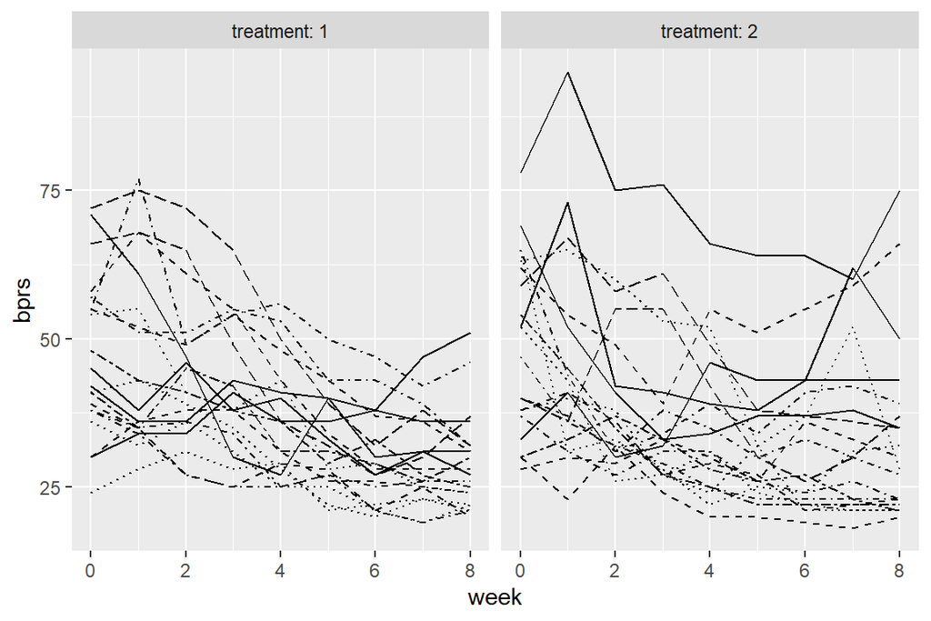

```r
ggplot(BPRSL, aes(x = week, y = bprs, linetype = subject)) +
  geom_line() +
  scale_linetype_manual(values = rep(1:10, times=4)) +
  facet_grid(. ~ treatment, labeller = label_both) +
  theme(legend.position = "none") +
  scale_y_continuous(limits = c(min(BPRSL$bprs), max(BPRSL$bprs)))
```

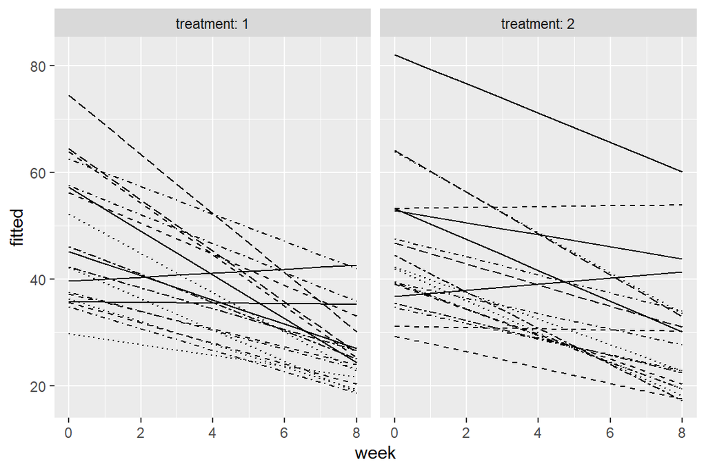

```r
Fitted <- fitted(BPRS_ref1)

BPRSL <- mutate(BPRSL, fitted = Fitted)

ggplot(BPRSL, aes(x = week, y = fitted, linetype = subject)) +
  geom_line() +
  scale_linetype_manual(values = rep(1:10, times=4)) +
  facet_grid(. ~ treatment, labeller = label_both) +
  theme(legend.position = "none") +
  scale_y_continuous(limits = c(min(BPRSL$fitted), max(BPRSL$fitted)))
```

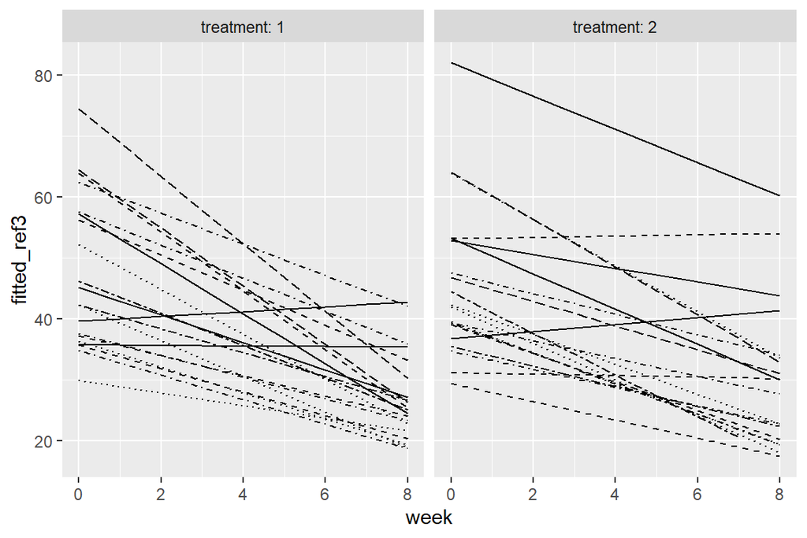

```r
Fitted_ref3 <- fitted(BPRS_ref3)

BPRSL <- mutate(BPRSL, fitted_ref3 = Fitted_ref3)

ggplot(BPRSL, aes(x = week, y = fitted_ref3, linetype = subject)) +
  geom_line() +
  scale_linetype_manual(values = rep(1:10, times=4)) +
  facet_grid(. ~ treatment, labeller = label_both) +
  theme(legend.position = "none") +
  scale_y_continuous(limits = c(min(BPRSL$fitted), max(BPRSL$fitted)))
```

I don’t understand what the convergence error means and whether I can still interpret this model? If I interpret it anyhow, from the anova I would see that the model 1 ( *random intercept and random slope model with two explanatory variables* ) is not a better fit than model 3 ( *random intercept and random slope model with only one explanatory variable, week* ). Overall, this would mean that time, not the differences between the treatments, explains the development of the bprs scores. There is also some between-individual heterogeneity and within-individual biological variation that the model takes into account.

I draw the fitted value plots for both models: *random intercept and random slope model with two explanatory variables* and *random intercept and random slope model with only one explanatory variable, week*. These plots look very similar. I don’t know how to interpret the fit of the model from these plots: When comparing to the original picture with the actual bprs scores, I think the fitted value -pictures look very simple. In the original photos there seem to be a lot of “noise” and not so linear trajectories.